# Global Pol II footprint-positive LCL clustering

# Clustering at TSS within Pol II ChIP peaks

The goal of the this analysis is to see promoter states at TSS. The reads that enter the clustering must have a Pol II ChIP-seq peak and have a 30-60 bp long footprint within the read

A read is eligible if it covers the whole 2 kb window around a selected TSS and carries a 30–60 bp FiberHMM footprint in that window. Clustering then uses a random 5,000 of the eligible molecules

**To calculate the m6a proportions in each clusters, each of 40 bins of 50 bp**, I used possible m6a positions pooled from all eligible reads at that TSS, including reads without a footprint

1. denominator: observed A/T sites. For each TSS, every full-span read there is pooled, across all 31 samples and including reads without a footprint. Any position, relative to the TSS, where at least one of those reads has an m6A call counts as an observed site
2. for each read r at TSS t and each of the 40 bins of 50 bp
- methylation(r, bin) = (r’s m6a calls in the bin) / (observed sites at t in that bin)
3. cluster methylation profile
- profile(cluster, bin) = mean over methylation(r, bin)

**Dominant TSS for each gene are used, which is selected as:**

1. Build the consensus of CAGE TSS
- Each input record represents a single genomic base with a CAGE tag count and strand. A site is retained only if the exact same base on the same strand has at least one tag in all three replicates. Nearby bases are not merged into clusters
2. Sum tag counts across the 3 replicates
3. Find nearby annotated GENCODE v46 TSS near the consensus site in 3 replicates
- Use GENCODE v46 transcripts on chromosomes 1–22 and X. A consensus site is eligible for a transcript if it is on the same chromosome and strand and lies within 250 bp of its annotated TSS, in either direction. All transcript isoforms are considered
4. Exclude CAGE TSS beyond the transcript end
5. Assign each consensus site to one gene
- Among eligible transcript matches, retain those with the smallest distance to an annotated TSS. If equally close matches belong to different genes, discard that CAGE site as ambiguous. Multiple equally close transcript matches within one gene can remain
6. Choose the dominant CAGE consensus TSS for each gene
- Select the assigned site with the highest summed CAGE count

**I also want to connect pausing index to the clustes, so I calculated pausing index following the steps by Day et al. 2016 using Pol II ChIP-seq data**

1. Start with hg38 RefSeq transcripts on chromosomes 1–22 and X. Remove genes whose isoforms occur on multiple chromosomes or strands
2. Pool seven Pol II ChIP-seq replicates and, separately, two input-control replicates. Within each replicate, collapse reads sharing the same genomic 5′ position and strand. Each remaining read contributes one count at its 5′ end. Region counts combine both read strands
3. Measure signal around each candidate TSS (TSSR)
- For every distinct annotated TSS, define a 350-bp TSS region: −50 through +299 bp, oriented in the direction of transcription
- Normalize ChIP and input counts separately:

$$\text{density} = \frac{\text{region read
count}}{\text{region length in bp} \times \left(\frac{\text{pooled
library reads}}{10^6}\right)}$$

- Then subtract background: corrected signal=“ChIP density − input density
4. Choose one TSS and transcript per gene
- Select the annotated TSS with the highest corrected TSS-region signal. If multiple transcripts share that TSS, choose the longest transcript, which determines the transcript end
5. Measure gene-body signal. Define the body as +300 bp after the selected TSS through 3,000 bp beyond the transcript end, following transcription direction. Calculate its length-normalized, library-normalized ChIP density and subtract the corresponding input density, as above
6. Calculate the pausing index
- $PI = \frac{\text{corrected TSS-region signal}}{\text{corrected gene-body signal}}$

Calculate PI only when the corrected TSS-region signal is ≥0.001 reads per million per bp and corrected body signal is >0. Otherwise, record PI as missing. For example, TSS-region signal of 0.02 and body signal of 0.005 give PI = 4

```r
knitr::opts_chunk$set(echo = FALSE, warning = FALSE, message = FALSE)
example_gene <- NULL
recompute_autocorrelation <- FALSE
recompute_nucleosome <- FALSE

if (!is.null(params$example_gene)) example_gene <- params$example_gene
library(data.table)
library(ggplot2)
cfg <- yaml::read_yaml(file.path(params$output, "run_config.yaml"))
here <- file.path(cfg$project, "code/pausing/clustering_Pol2")
source(file.path(here, "pol2_chip_cluster_utils", "pol2_clustering_functions.R"))
source(file.path(here, "pol2_chip_cluster_utils", "pol2_molecule_tables.R"))
source(file.path(here, "pol2_chip_cluster_utils", "pol2_clustering_plots.R"))

pol2_load_helpers(cfg$project)
source(file.path(here,"pol2_chip_cluster_utils/pol2_observed_profiles.R"))
x <- readRDS(file.path(params$output, "tables", "clustering.rds"))
annotation <- readRDS(file.path(params$output, "tables", "annotations.rds"))
annotation <- pol2_numeric_annotation(annotation)
m <- annotation$molecules
res <- pol2_heatmap_result(x, annotation, cfg$heatmap_max_reads, cfg$seed)
sample_colors <- pol2_sample_colors(cfg, res$assignments$sample_name)
clusters <- levels(res$assignments$cluster)
k <- length(clusters)

observed_masks <- pol2_observed_masks(cfg,x,genes=example_gene)
if (is.null(example_gene)) {
  observed_profile <- pol2_observed_profile(x$sites,res$assignments,observed_masks,
    x$molecules$tss_id[match(res$assignments$RID,x$molecules$observation_id)])
  fwrite(observed_profile,file.path(cfg$output,"tables/observed_site_profiles/cluster_per_site_profiles.tsv.gz"),sep="\t")
}
```

## Clustering

clusters individual Fiber-seq molecules by their m6A accessibility patterns around TSSs, pooling all 31 LCL samples

```
1. select TSSs associated with Pol II. Start with dominant FANTOM5 TSSs on chromosomes 1–22 and X. Keep a TSS only if its exact position overlaps a reproducible Pol II ChIP-seq peak

2. define a 2-kb window around each TSS. Use positions −1,000 through +999, oriented by the gene’s strand so that upstream and downstream align consistently. Exclude windows extending beyond chromosome boundaries

3. select eligible molecules. A molecule must span the entire 2-kb window and have at least one FiberHMM footprint of 30–60 bp overlapping that window, using footprint calls from its own sample. This footprint criterion does not itself establish that the footprint is Pol II

4. build the m6A accessibility profile. Divide each window into 40 bins of 50 bp. For each bin: Identify distinct genomic positions with an m6A call in any full-window molecule pooled across samples, including molecules without qualifying footprints

- divide each eligible molecule’s distinct m6A calls in the bin by that number of observed positions

- For example, in one 50-bp bin:

Across all full-span molecules, 20 distinct genomic positions have an m6A call somewhere

- read A has modifications at 6 of those positions -> 6/20 = 0.30
- read B has modifications at 10 of those positions -> 10/20 = 0.50

5. sample molecules for clustering. Randomly select 5,000 distinct molecules from the pooled eligible population, without replacement. If a selected molecule qualifies at multiple TSSs, randomly choose one of its eligible TSS observations. Sampling is global, without equal quotas per sample or TSS

6. measure similarity between molecules. Compare their 40-bin profiles using Manhattan distance

7. identify clusters. Connect each molecule to its 10 nearest neighbors, giving stronger weights to more similar molecules. Run Leiden clustering with resolution 1 to identify groups with similar profiles

8. **assign the remaining molecules to the discovered clusters**

  - *this may not be a good way to assign reads to clusters, but i don't know if it is feasible to do clustering on all the reads?*

    a. only the sampled 5000 molecules are used to discovered the clusters, the remaining eligible molecules are assigned to the existing clusters
    b. take one remaining molecule's binned accessibility profile --> find 10 sampled molecules with the most similar profiles by Manhattan distance
    c. count their cluster labels, assign the remaining molecules to the cluster with the most counts
```

- If there is a tie, compare the closest neighboring belong the 2 clusters, whichever of those clusters has the closet neighbor (by smallest distance) wins

Heatmap of the 5,000 randomly sampled reads used for clustering, grouped by cluster: each row is one read’s m6A calls across the TSS +/- 1 kb window. Top panels show cluster’s m6A fraction at observed sites

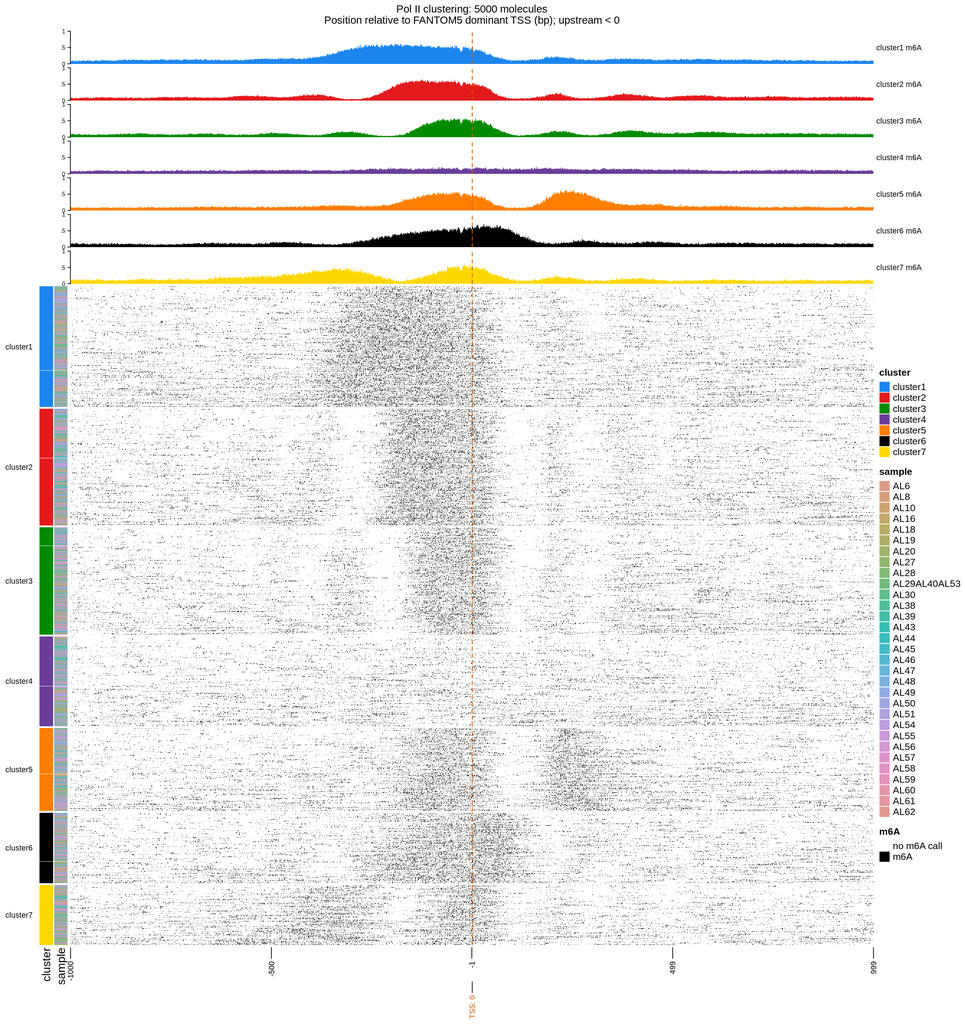

Clusters ordered by median pausing index (lowest on top): the same reads (left), each cluster’s mean m6A profile in 50 bp bins (middle) and Pol II enrichment (right)

Pol II enrichment: each TSS gets the mean Pol II ChIP fold-enrichment over input bigwig ( ENCFF328MMS) from −50 to +299 bp, each read takes its TSS’s value, and the bar is log2(cluster mean / mean of all 5,000 reads); stars are a Wilcoxon test of the cluster vs. all other reads, BH-adjusted

- < 0.05 ** < 0.01 *** < 0.001

How pausing index is assigned to each cluster (PI labels and cluster order in this figure):

1. Each gene has one pausing index from `pause_index.tsv` (Day et al. steps, Pol II ChIP), matched to the read’s TSS by Ensembl gene ID
2. For each cluster, take the distinct TSSs of its clustered reads that have a PI. A TSS counts once per cluster, however many of its reads are in that cluster
3. Cluster PI = median PI of those TSSs, shown as “PI: median (n TSSs)” on each profile
4. Clusters are ordered by this median, lowest at the top

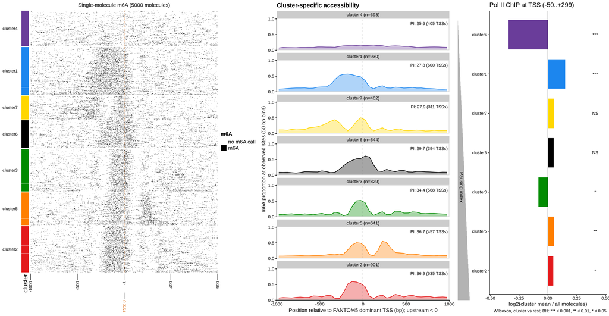

| cluster | n | n_with_signal | mean_tss_signal | log2_ratio | p | fdr | signif | median_pi | n_tss_with_pi | display_order |
| --- | --- | --- | --- | --- | --- | --- | --- | --- | --- | --- |
| cluster1 | 930 | 930 | 23.412 | 0.149 | 0.000 | 0.000 | *** | 27.788 | 600 | 2 |
| cluster2 | 901 | 901 | 21.816 | 0.047 | 0.036 | 0.050 | * | 36.864 | 635 | 7 |
| cluster3 | 829 | 829 | 19.936 | -0.083 | 0.031 | 0.050 | * | 34.372 | 568 | 5 |
| cluster4 | 693 | 693 | 16.666 | -0.341 | 0.000 | 0.000 | *** | 25.627 | 405 | 1 |
| cluster5 | 641 | 641 | 21.904 | 0.053 | 0.001 | 0.003 | ** | 36.665 | 457 | 6 |
| cluster6 | 544 | 544 | 21.859 | 0.050 | 0.070 | 0.082 | NS | 29.699 | 394 | 4 |
| cluster7 | 462 | 462 | 21.920 | 0.054 | 0.426 | 0.426 | NS | 27.865 | 311 | 3 |

Where the 30–60 bp footprints sit on the clustered reads: histogram of footprint midpoints relative to the TSS

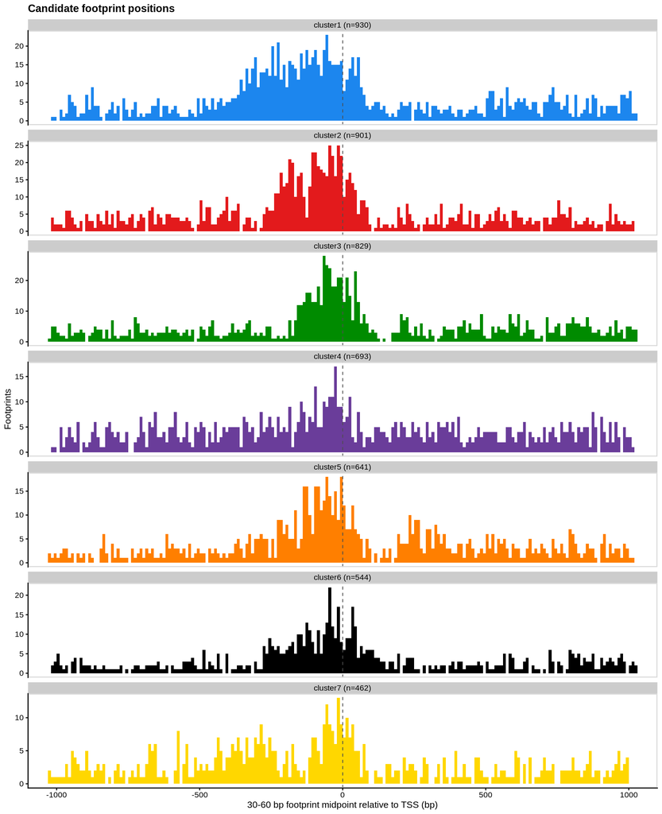

All nucleosome and FiberHMM TF footprints on the 5,000 clustered reads, one row per read in the same order as the first heatmap, coloured by footprint size class.

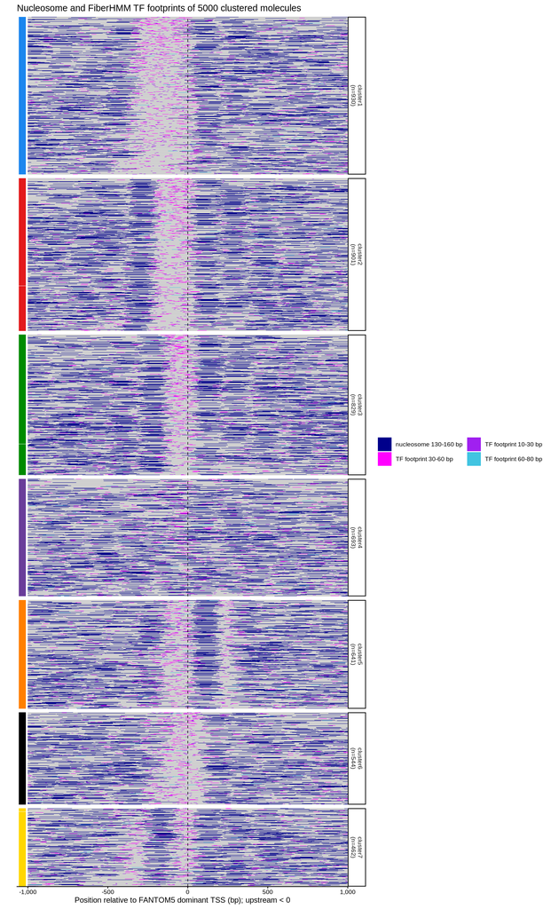

Pausing index of the TSSs in each cluster (one value per TSS per cluster, log scale)

PI is joined by Ensembl gene ID. *I used the RefSeq TSS of `pause_index.tsv` to calculate pausing index following Day et al. steps, but used FANTOM5 dominant TSS per gene to annotate the TSS of the reads -> not sure if this is a problem?*

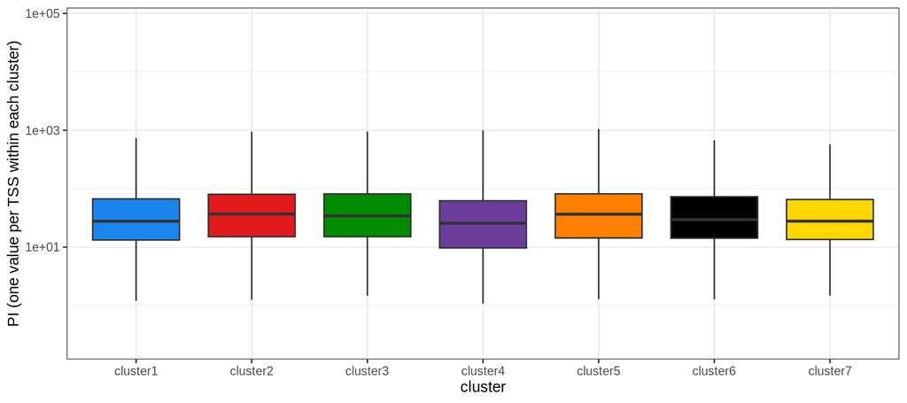

## Example loci in cluster 4 (inaccessible cluster)

I chose some loci in cluster4 to look at because they contain the most appearant chromatin states, which is mostly inaccessible

- reads are grouped by cluster, with gene models, GTEx LCL eQTL variants and each cluster’s m6A profile. Reads outside the 5,000 clustered take the majority cluster of their 10 nearest clustered reads

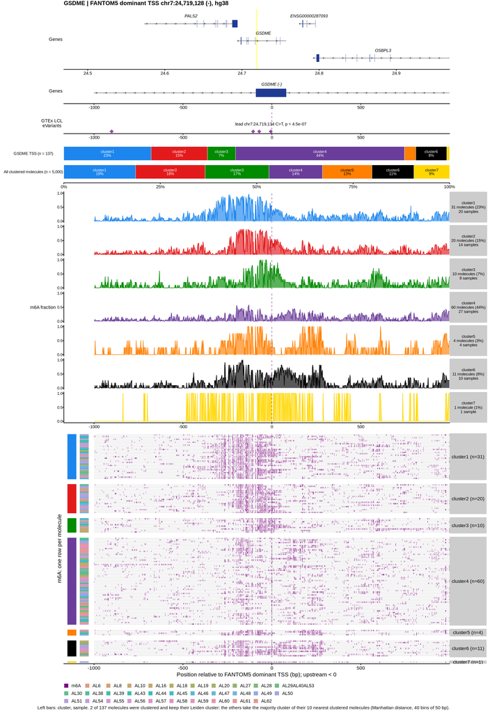

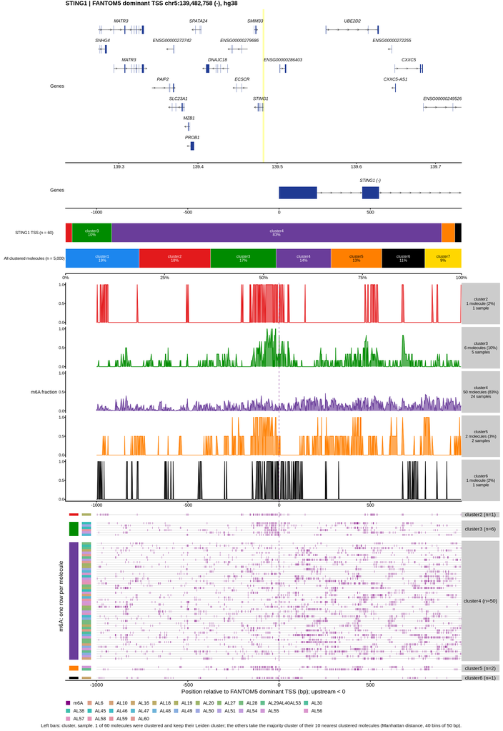

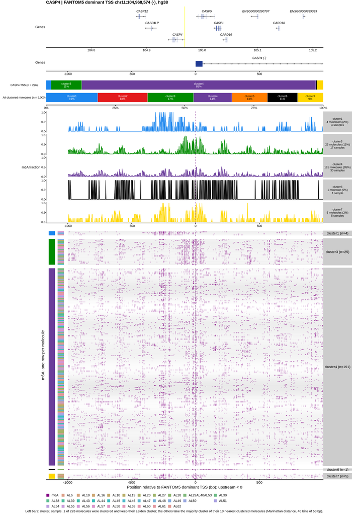

## Selected promoters: motif and read-level cluster examples

I want to move beyond cluster4 and to select one promoter representative of each cluster to look at. I just chose the protein coding genes, and that 100 reads in all samples and the TSS with the highest fraction of reads in the cluster

| cluster | gene_name | n_cluster | n_total | n_samples | fraction |
| --- | --- | --- | --- | --- | --- |
| cluster1 | ARF4 | 204 | 206 | 31 | 0.990 |
| cluster2 | MCOLN1 | 141 | 160 | 31 | 0.881 |
| cluster3 | PSMC1 | 301 | 337 | 31 | 0.893 |
| cluster4 | GAS2 | 251 | 260 | 31 | 0.965 |
| cluster5 | FNTB | 222 | 240 | 31 | 0.925 |
| cluster6 | TPK1 | 124 | 184 | 31 | 0.674 |
| cluster7 | EIF2S1 | 271 | 293 | 31 | 0.925 |

Footprint and accessibility profile for each of the example. I also want to see if any of the example would be enriched for any particular promoter TSS as in *Sequence basis of transcription initiation in human genome* paper

-> I’m not sure if this is a good way of doing this to just look at single example, because it seems that none of the motifs has a lot of overlap with the footprints. But I don’t know how to look at all the promoters in the cluster together as they have different sequence?

- a motif is supported if one 10-30bp footprint covering at least 50% of one full motif interval on that same read

The motifs they looked at are:

1. directional motifs
1. TATA: the most position- and strand-specific effect of any motif 2) YY1: highly strand-specific and activates initiation immediately upstream of the motif and about 220 bp upstream.
2. bidirectional motifs
1. NFY, SP (KLF/SP), ETS, ZNF143, CREB/ATF and NRF1: nearly symmetric effects on both strands

```
- NFY has a distinctive effect curve with about 10.5-bp periodicity, matching DNA helical pitch and possibly reflecting a rigid NF-Y–PIC interaction
- SP and NRF1: CG-rich SP motif is the most common promoter motif. NRF1 is the only palindromic motif
```

Motif occurrence supported by at least 50% overlap with 10-30 bp TF footprint by percentage for each cluster

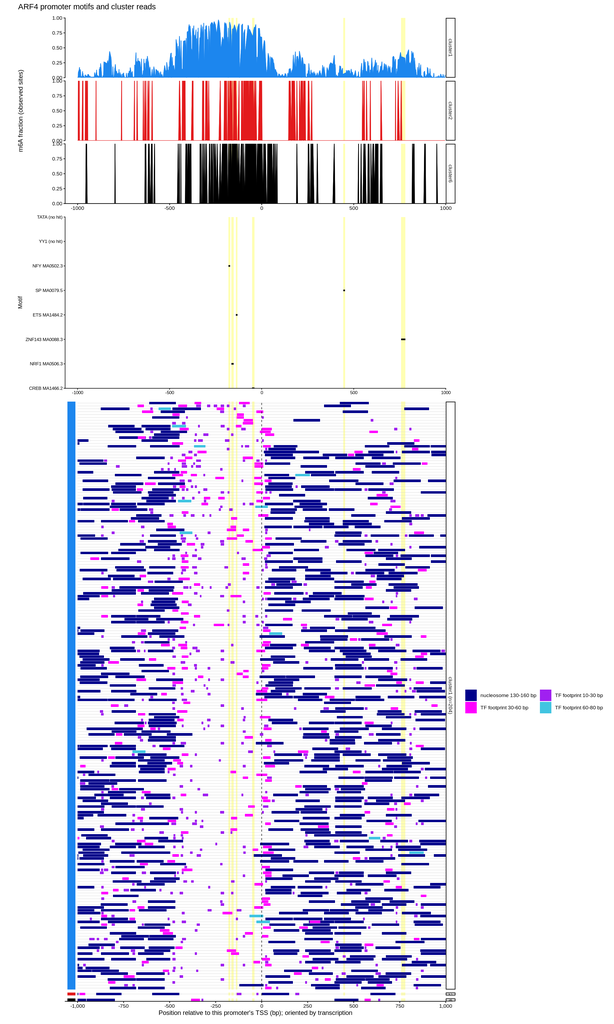

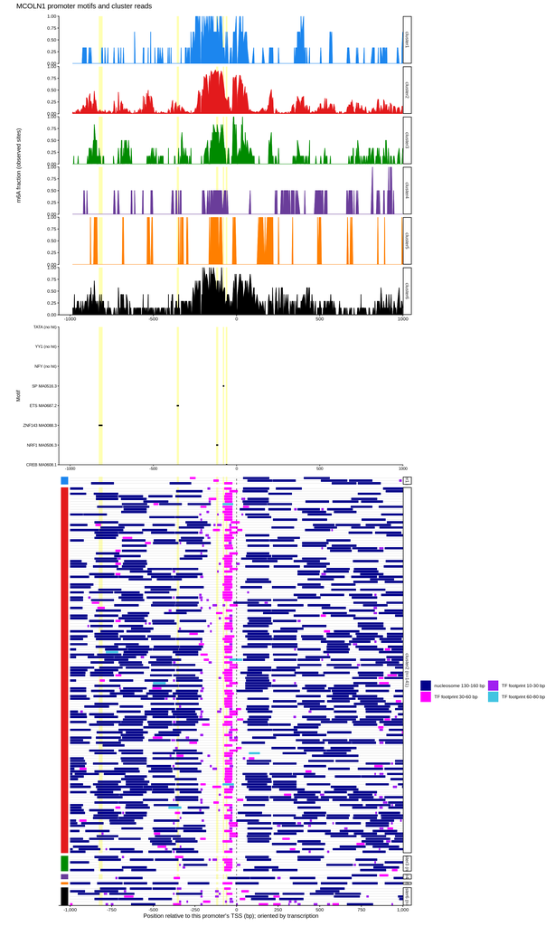

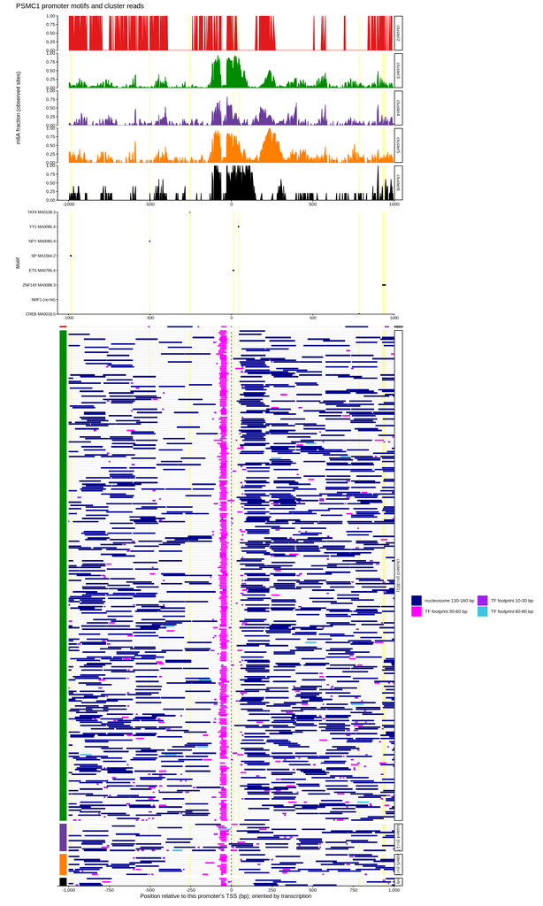

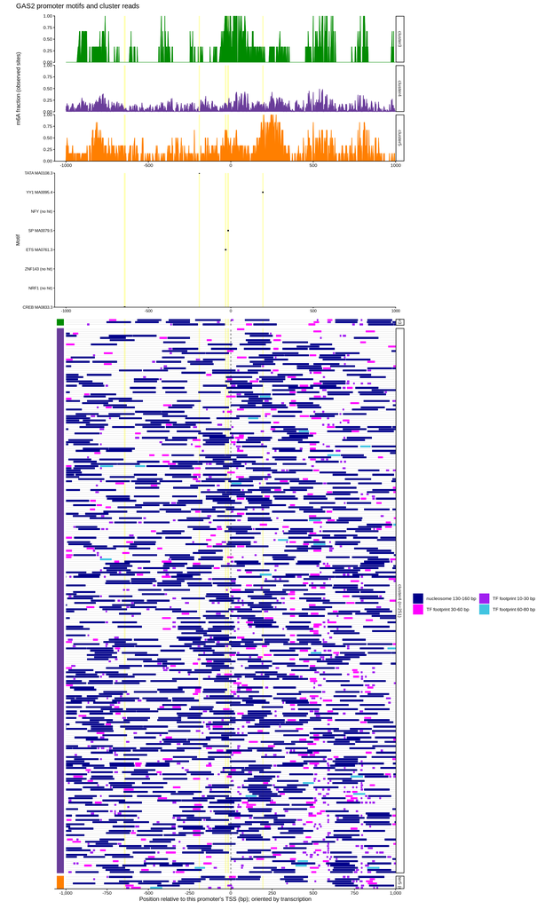

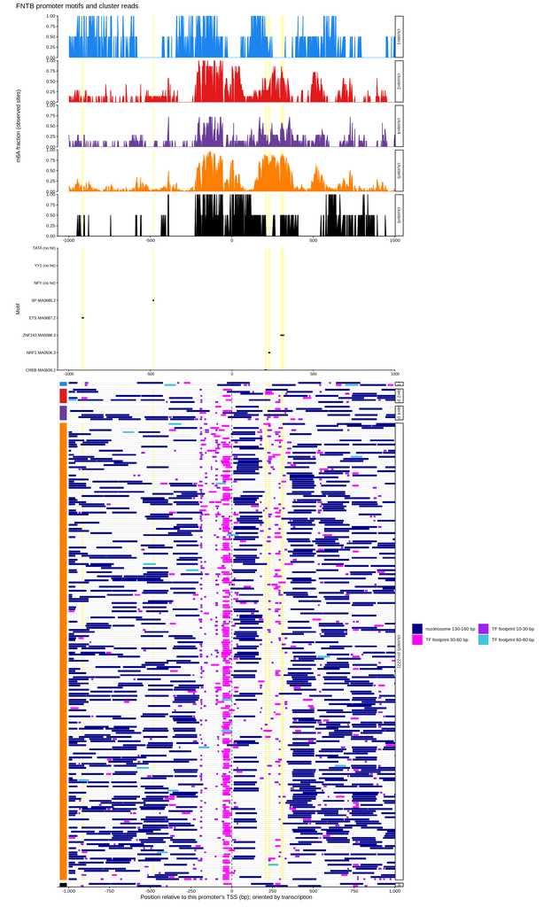

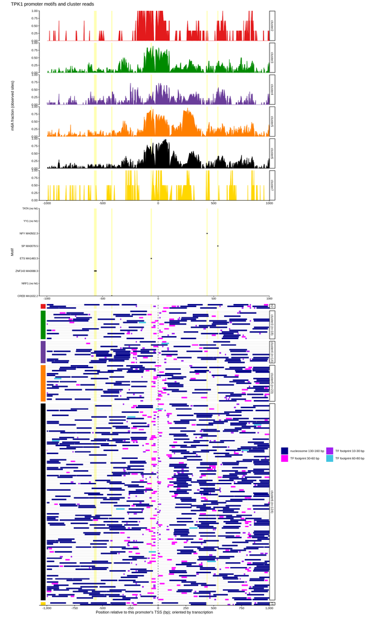

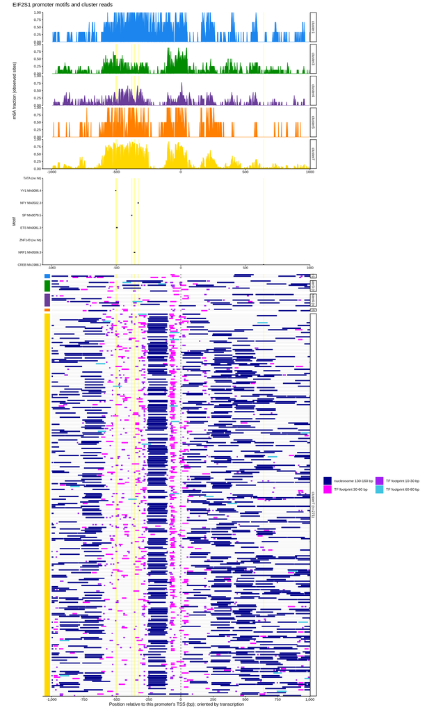

## Features of the 5,000 clustered molecules

m6A, CpG methylation, GRO-cap and DNase of the 5,000 clustered reads, one box per cluster. Diamonds show each cluster’s pooled value. The values are computed by `--stage report`; this chunk only re-plots the saved tables, so CpG is not extracted again.

1. m6A fraction
- observed sites: every position in the TSS +/- 1 kb window where any full-span read at that TSS (all 31 samples, with or without a footprint) has an m6A call
- read value = the read’s m6A calls in the window / observed sites at its TSS
- diamond = sum of calls / sum of observed sites over the cluster’s reads
2. CpG methylation fraction
- pb-CpG-tools (count mode) on each cluster’s reads gives, at every CpG, the reads covering it and the reads calling it methylated
- keep the CpGs inside the cluster’s TSS windows (TSS +/- 1 kb)
- value = methylated reads / covering reads, summed over the CpGs of one TSS window; every read at that TSS in that cluster gets this value
- diamond = the same ratio over all CpGs in all the cluster’s windows, each CpG counted once
3. GRO-cap
- sense-strand GRO-cap signal (plus-strand bigWig for “+” genes, minus-strand bigWig for “−” genes) summed over the 2 kb window
- every read at that TSS gets this value, plotted as log10(x + 1); diamond = mean over the cluster’s reads
4. DNase
- mean DNase-seq signal (ENCFF743ULW) over the 2 kb window
- every read at that TSS gets this value; plotted as log10(x + 1), diamond = mean over the cluster’s reads

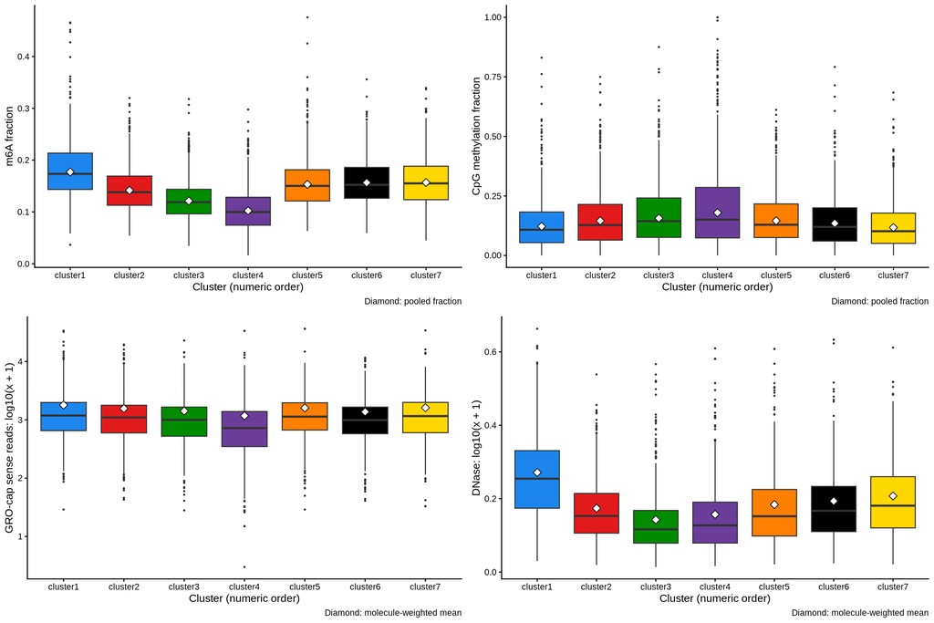

| cluster | n_molecules | n_tss | pooled_m6a | median_m6a | median_grocap | median_dnase | mean_grocap | mean_dnase | pooled_cpg | n_cpg_sites | median_cpg_coverage |
| --- | --- | --- | --- | --- | --- | --- | --- | --- | --- | --- | --- |
| cluster1 | 930 | 791 | 0.177 | 0.174 | 1186 | 0.797 | 1792.102 | 0.868 | 0.122 | 90512 | 1 |
| cluster2 | 901 | 819 | 0.142 | 0.138 | 1097 | 0.421 | 1560.952 | 0.493 | 0.145 | 85805 | 1 |
| cluster3 | 829 | 748 | 0.121 | 0.119 | 999 | 0.308 | 1417.774 | 0.389 | 0.157 | 70331 | 1 |
| cluster4 | 693 | 634 | 0.102 | 0.100 | 722 | 0.341 | 1174.685 | 0.436 | 0.180 | 57189 | 1 |
| cluster5 | 641 | 588 | 0.153 | 0.150 | 1133 | 0.419 | 1599.725 | 0.527 | 0.145 | 63469 | 1 |
| cluster6 | 544 | 501 | 0.156 | 0.152 | 989 | 0.469 | 1369.665 | 0.561 | 0.135 | 53989 | 1 |
| cluster7 | 462 | 414 | 0.157 | 0.155 | 1159 | 0.517 | 1611.881 | 0.612 | 0.117 | 45786 | 1 |

## autocorrelation profile per read for each cluster

Computed by `--stage autocorrelation`

Autocorrelation of each read’s 1 bp m6A calls upstream (−500 to −25 bp) and downstream (+25 to +500 bp) of the TSS, averaged per cluster; a peak at 140–250 bp lag suggests regularly spaced nucleosomes.

[figure not shown]

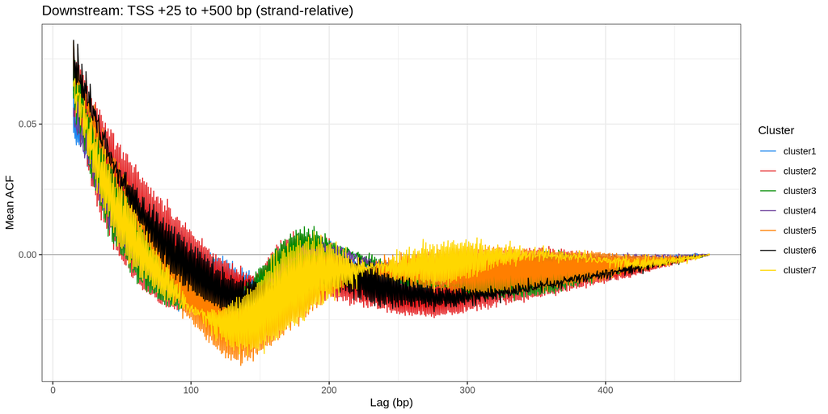

The same curves, one panel per cluster; the table gives each cluster’s peak lag (140–250 bp) and its autocorrelation.

[figure not shown]

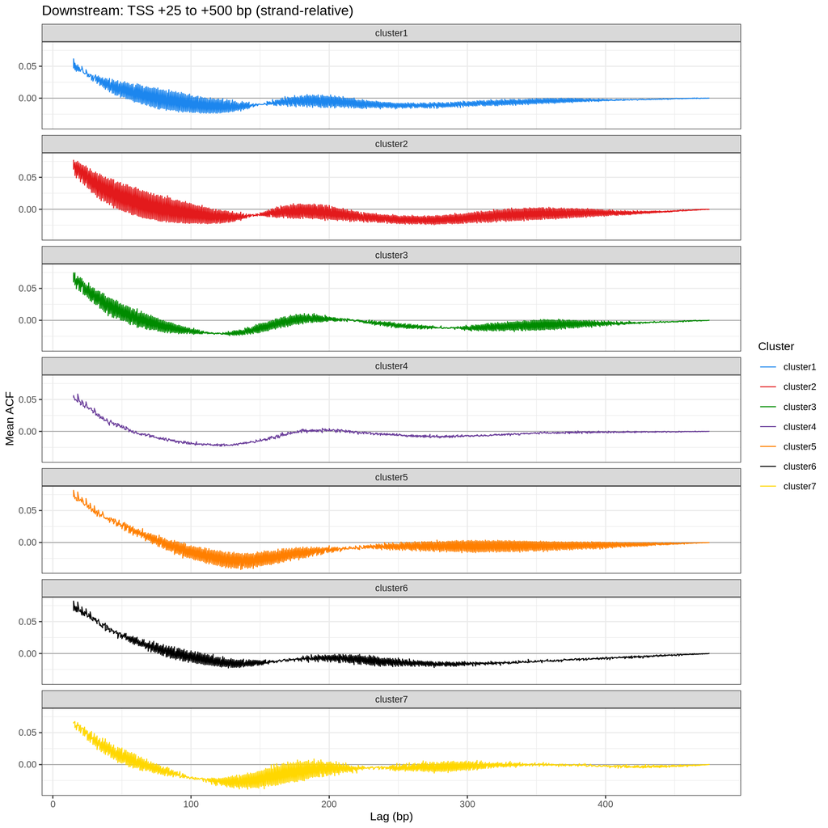

| cluster | window | window_start_bp | window_end_bp | positive_local_peak_140_250_bp | peak_acf |
| --- | --- | --- | --- | --- | --- |
| cluster1 | upstream | -500 | -25 | NA | NA |
| cluster2 | upstream | -500 | -25 | NA | NA |
| cluster3 | upstream | -500 | -25 | 212 | 0.0018 |
| cluster4 | upstream | -500 | -25 | 203 | 0.0029 |
| cluster5 | upstream | -500 | -25 | NA | NA |
| cluster6 | upstream | -500 | -25 | NA | NA |
| cluster7 | upstream | -500 | -25 | 249 | 0.0019 |
| cluster1 | downstream | 25 | 500 | 184 | 0.0057 |
| cluster2 | downstream | 25 | 500 | 174 | 0.0088 |
| cluster3 | downstream | 25 | 500 | 189 | 0.0108 |
| cluster4 | downstream | 25 | 500 | 195 | 0.0048 |
| cluster5 | downstream | 25 | 500 | NA | NA |
| cluster6 | downstream | 25 | 500 | NA | NA |
| cluster7 | downstream | 25 | 500 | 189 | 0.0088 |

The same mean autocorrelation as a heatmap: clusters by lag, colour = autocorrelation.

[figure not shown]

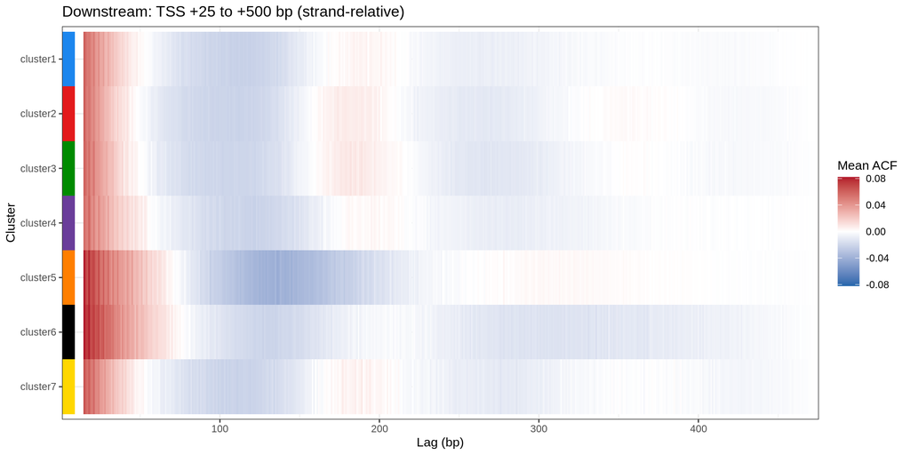

## Nucleosome positioning at TSS of each cluster

Computed by `--stage nucleosome`

Per cluster: fraction of reads with a nucleosome covering each position (first plot, 10 bp grid) and number of nucleosome centres in 25 bp bins (second plot).

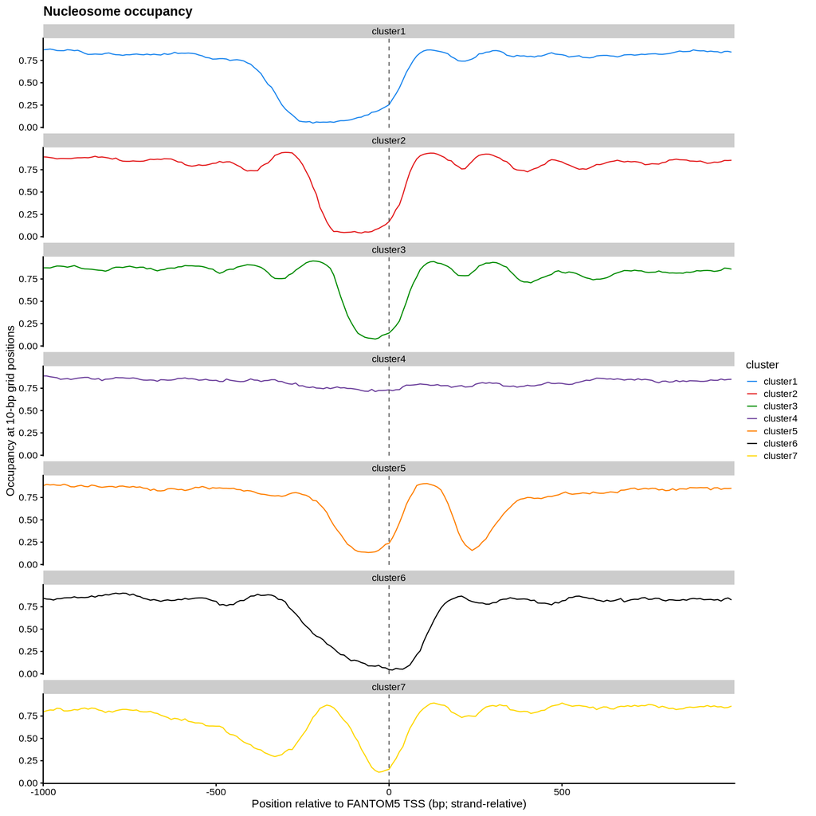

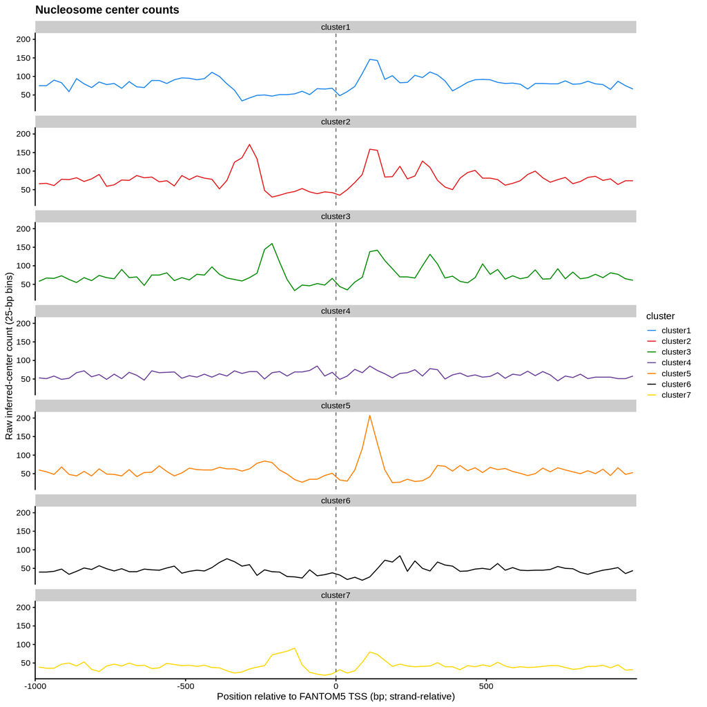

How the −1 and +1 nucleosome positions are found:

1. Reads: the 5,000 clustered reads; each spans the whole TSS +/- 1 kb window
2. Nucleosomes: every footprint block on the read from its sample’s FiberHMM `recalled_footprint.bed.gz` that overlaps the window (no size filter)
3. Each footprint is placed at its midpoint, relative to the TSS and oriented by the gene’s strand (upstream < 0)
4. −1 = the footprint whose midpoint is closest to the TSS on the upstream side (< 0); +1 = the closest midpoint at or downstream of the TSS (>= 0)
5. A read with no footprint on one side has no value for that side
6. Boxes show these midpoints over the reads of each cluster, one panel for −1 and one for +1

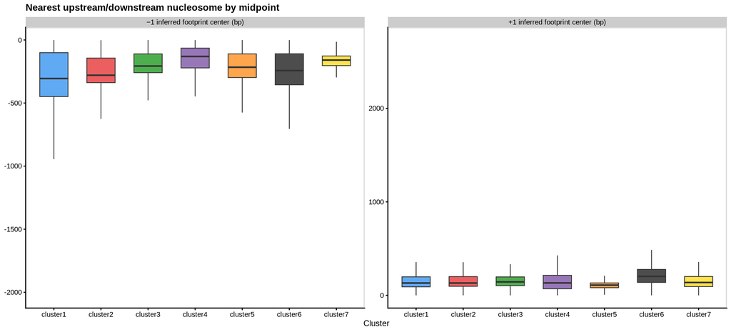

Fraction of reads with a nucleosome covering the TSS in each cluster, with 95% bootstrap intervals (resampling promoters and samples).

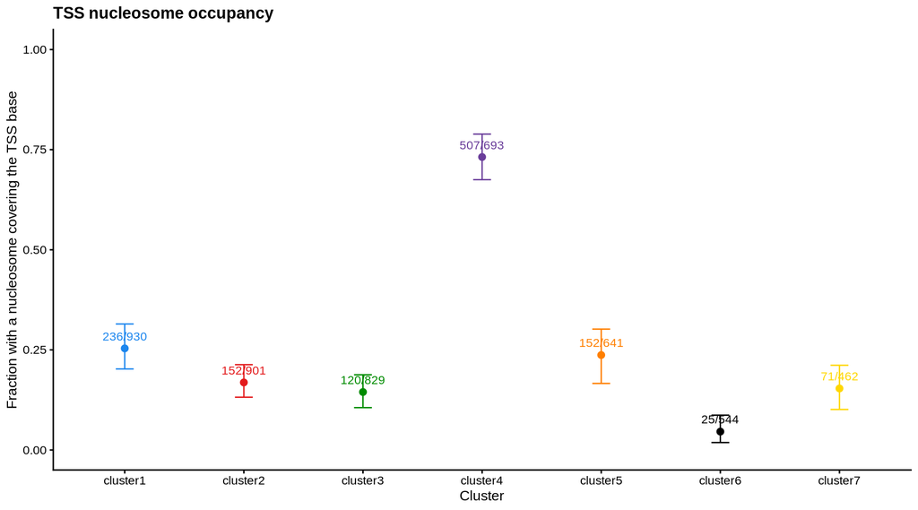

| cluster | n_reads | n_minus1 | minus1_median | n_plus1 | plus1_median | occupied_count | n_promoters | n_samples | frac_anchor_occupied | tss_lower | tss_upper |
| --- | --- | --- | --- | --- | --- | --- | --- | --- | --- | --- | --- |
| cluster1 | 930 | 929 | -305.50 | 930 | 132.0 | 236 | 791 | 31 | 0.254 | 0.202 | 0.315 |
| cluster2 | 901 | 901 | -279.50 | 901 | 132.0 | 152 | 819 | 31 | 0.169 | 0.132 | 0.213 |
| cluster3 | 829 | 829 | -206.50 | 829 | 144.0 | 120 | 748 | 31 | 0.145 | 0.106 | 0.188 |
| cluster4 | 693 | 693 | -130.50 | 693 | 133.0 | 507 | 634 | 31 | 0.732 | 0.675 | 0.789 |
| cluster5 | 641 | 641 | -216.00 | 641 | 109.5 | 152 | 588 | 31 | 0.237 | 0.166 | 0.302 |
| cluster6 | 544 | 543 | -242.50 | 544 | 203.5 | 25 | 501 | 31 | 0.046 | 0.019 | 0.087 |
| cluster7 | 462 | 462 | -159.25 | 462 | 137.5 | 71 | 414 | 31 | 0.154 | 0.101 | 0.212 |

## Histone marks at the TSS

Bulk GM12878 histone ChIP-seq fold change over control around each clustered molecule’s FANTOM5 TSS, strand-oriented. Each 50-bp bin is the coverage weighted mean signal

How the histone profiles are calculated:

1. Marks: GM12878 ChIP-seq fold change over control
2. Window: TSS −2,000 to +2,000 bp, oriented by the gene’s strand, split into 50 bp bins
3. Per TSS and bin: mean ChIP signal over the bin, each bigWig value weighted by the bases it covers
4. Per cluster: each of the 5,000 clustered reads takes its TSS’s values, and the cluster’s curve is the mean over its reads, so a TSS counts once per read it has in the cluster. Bins without ChIP signal are left out of the mean

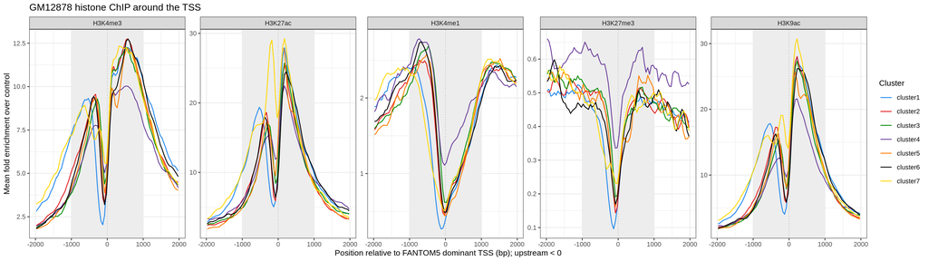

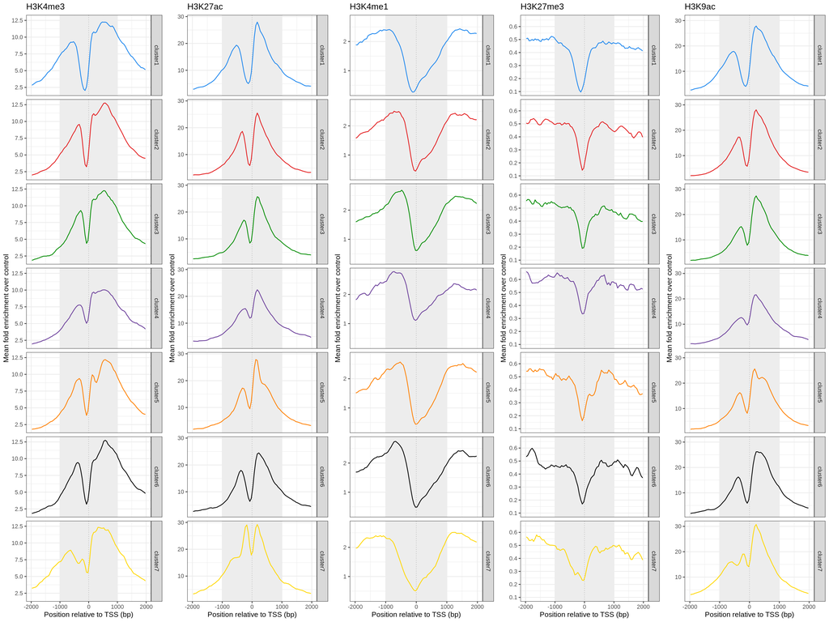

## Run configuration

Settings and input paths used for this report: `run_config.yaml` in the output folder, written by the report stage from `pol2_chip_cluster_utils/config.yaml`.

```yaml
project: /project/spott/cshan/fiber-seq
samples: /project/spott/1_Shared_projects/LCL_Fiber_seq/Data/LCL_sample_metatable_merged_samples_31samples.csv
expected_samples: 31
tss: /project/spott/cshan/annotations/fantom5_LCL/fantom5.hg38.LCL.dominant_TSS.bed.gz
chrom_sizes: /project/spott/cshan/annotations/hg38.chrom.sizes
footprint_dir: /project/spott/1_Shared_projects/LCL_Fiber_seq/FiberHMM/FiberHMM_v2/results/results_v1_trained_model
peaks: /project/spott/cshan/annotations/LCL_public_data/Pol2_chip/ENCFF886PSD.bed.gz
signal: /project/spott/cshan/annotations/LCL_public_data/Pol2_chip/ENCFF328MMS.bigWig
output: /project/spott/cshan/fiber-seq/LCL_project/pausing/clustering_Pol2
chromosomes:
- chr1
- chr2
- chr3
- chr4
- chr5
- chr6
- chr7
- chr8
- chr9
- chr10
- chr11
- chr12
- chr13
- chr14
- chr15
- chr16
- chr17
- chr18
- chr19
- chr20
- chr21
- chr22
- chrX
bin_bp: 50
k_neighbors: 10
resolution: 1
seed: 1
sample_n: 5000
heatmap_max_reads: 5000
pi_table: /project/spott/cshan/fiber-seq/LCL_project/pausing/pause_index.tsv
locus_genes:
- GSDME
- STING1
- CASP4
gene_models: /project/spott/cshan/annotations/gencode.v46.annotation.gtf.gz
eqtl_pairs: /project/spott/cshan/annotations/LCL_public_data/GTEx_Analysis_v8_eQTL/Cells_EBV-transformed_lymphocytes.v8.signif_variant_gene_pairs.txt.gz
expression:
- /project/spott/cshan/annotations/LCL_public_data/gene_quan_ENCSR820PHH/ENCFF873VWU.gene_quan.tsv
- /project/spott/cshan/annotations/LCL_public_data/gene_quan_ENCSR820PHH/ENCFF345SHY.gene_quan.tsv
pb_cpg_tools: /project/spott/cshan/envs/pb-CpG-tools/bin/aligned_bam_to_cpg_scores
python: /project/spott/cshan/envs/Jupyter-notebook/bin/python3
reference: /project/spott/cshan/annotations/hg38.fa
grocap_plus: /project/spott/cshan/annotations/LCL_public_data/GRO_cap_ENCFF799JUK.bigWig
grocap_minus: /project/spott/cshan/annotations/LCL_public_data/GRO-cap/ENCFF368RBW.bigWig
dnase: /project/spott/cshan/annotations/LCL_public_data/DNase.ENCFF743ULW.bigWig
histone_marks:
  H3K4me3: /project/spott/cshan/annotations/LCL_public_data/histone_chip/H3K4me3_ENCFF927KAJ.bigWig
  H3K27ac: /project/spott/cshan/annotations/LCL_public_data/histone_chip/H3K27ac_ENCFF469WVA.bigWig
  H3K4me1: /project/spott/cshan/annotations/LCL_public_data/histone_chip/H3K4me1_ENCFF564KBE.bigWig
  H3K27me3: /project/spott/cshan/annotations/LCL_public_data/histone_chip/H3K27me3_ENCFF919DOR.bigWig
  H3K9ac: /project/spott/cshan/annotations/LCL_public_data/histone_chip/H3K9ac_ENCFF599TRR.bigWig
merged_bam_overrides:
  AL29AL40AL53_bc2171bc2141bc2132_18916: /project/spott/1_Shared_projects/LCL_Fiber_seq/final_merged_samples/AL29AL40AL53_bc2171bc2141bc2132_18916.5mC.6mA.nuc.aligned.bam
```